# Data Science on the Google Cloud Platform -- errata?

I believe there's an error in Chapter 3. In this chapter, we build a model based on a threshold on departure delay to make the decision to cancel the meeting or not.

In Chapter 1, it is stated that our decision criterion is:

> Cancel the client meeting if the likelihood of arriving 15 minutes early is 70% or less.

Since the planning includes a 30 minutes leeway, it means, we should cancel the client meeting if the likelihood of the flight being **on time** (i.e. 15 minutes late or less) is **70% or less**.

It is restated in the "Building Our First Model" section in chapter 3:

> recall that we wanted to cancel if the probability of an arrival delay of 15 minutes was greater than 30%

Later in chapter 3, under "Explaining a Contingency Table", the pie charts are misleading to me:

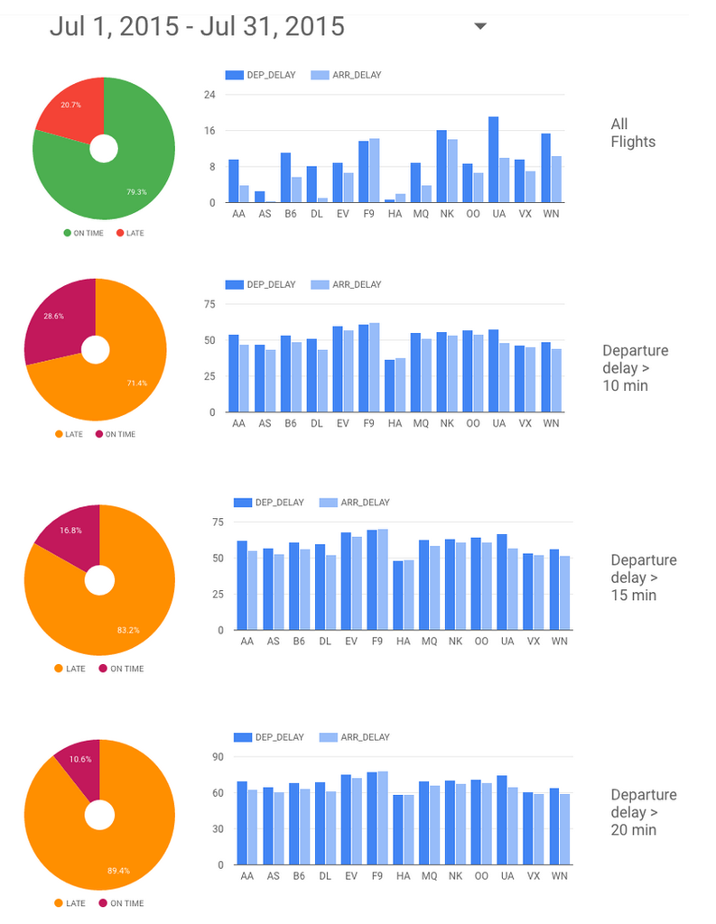

In the first chart, the upper left corner shows the percentage of flights that are **late** while it show the percentage of flights being **on time** in the 3 other charts.

Focusing on the likelihood of being **on time**, it goes from 79.3% for all flights down to 28.6% for flights with a delay of 10 minutes or more. So the delay that will give a likelihood of 70% is somewhere below 10 minutes, but where?

To get an answer to that, I plotted the percentage of flight on time for a range of departure delay thresholds. It turns out that if your flight doesn't depart between 0 and 5 minutes **earlier than planned**, you have a <70% chance of begin on time!

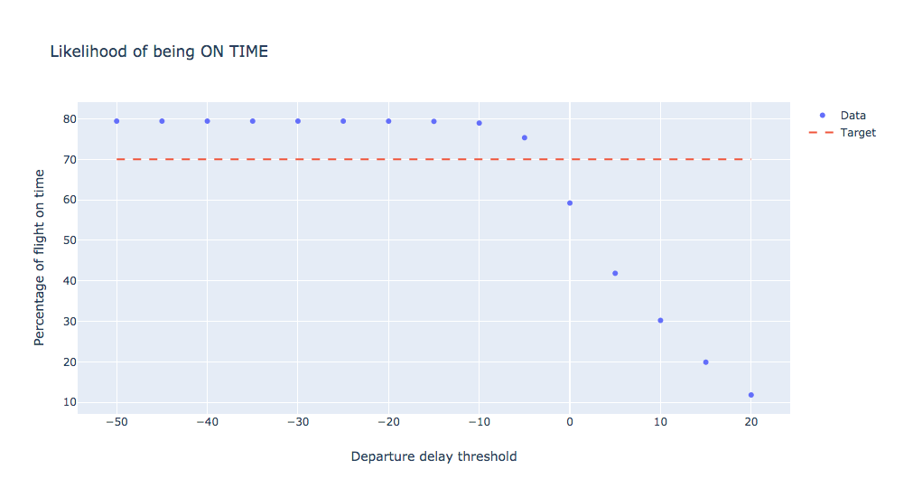

This means that rigth from the start, before you have any information about whether or not your flight will be late (the day before, say), you only have a 80% chance of begin on time. And if, by the time of the scheduled departure, you didn't leave, you're already at 60% in your chance of begin on time. So you should already cancel your meeting.

A good departure delay threshold would then be -5 minutes, not 10 minutes. Am I right?

For what it's worth, it aligns better with my experience with air travel! :)